# A15.11

[figure not shown]

セル周囲の一定の負のせん断流（大きさが等しい）：

$$q = \frac{M}{2A} = \frac{20323}{2 \times 493} = -20.6 \text{ lb./in.}$$

（ $493$ = セルの面積）

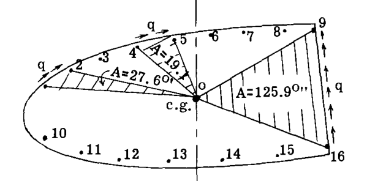

Fig. A15-28

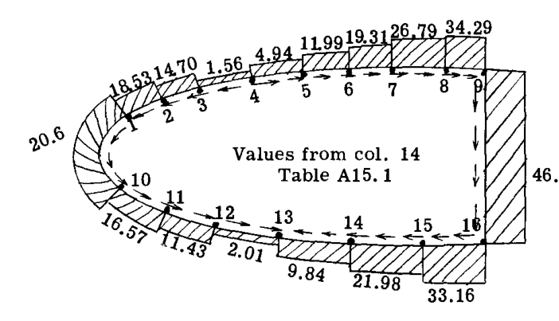

Fig. A15-29

## A15.9 2セル複数フランジ梁。1軸対称。

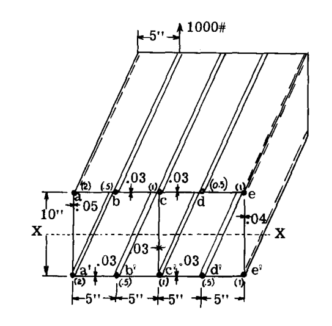

Fig. A15-30

### 解法1（せん断中心を使用しない方法）

各セル内の任意の点におけるせん断流が未知であるため、内部せん断流は2次不定である。したがって、曲げせん断流を静定にするために、各セル内のいくつかの点におけるせん断流 $q$ の値を仮定し、各セルの曲げせん断流を仮定された条件と矛盾しないように計算する。これらの結果として得られる静的なせん断流システムは、一般に、各セルの周囲で異なる総せん断ひずみを生じ、言い換えれば、異なるセルのねじれを生じる。セル間の完全な連続性が存在するため、この状態は存在し得ず、したがって、両方のセルのねじれを同一にするために、セル(1)の $q_1$ とセル(2)の $q_2$ の未知の一定せん断流を加えなければならない。この事実は1つの方程式の基礎を与え、2つの未知数 $q_1$ と $q_2$ の解法に必要なもう1つの方程式は、平衡の要件、すなわち、断面の平面内の任意の点の回りにおける外部および内部のせん断力のモーメントの和がゼロに等しくなければならないという要件によって与えられる。図 A15.31では、曲げせん断流は、セル(1)のストリンガー $c$ のすぐ左側、およびセル(2)のストリンガー $c$ のすぐ右側でゼロと仮定されている。この仮定と一致する曲げせん断システムのバランスは、次のように計算される：

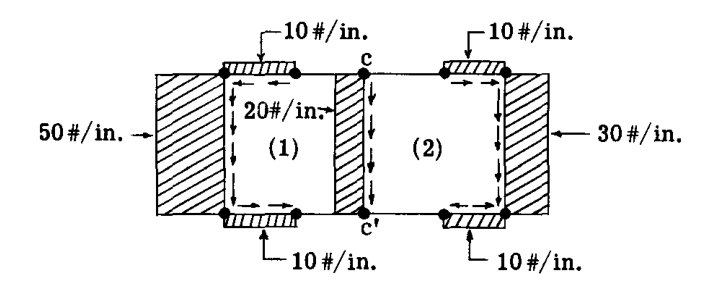

Fig. A15-31

一般的なせん断流方程式は、

$$q_y = -\frac{V_z}{I_x} \sum Z A = -\frac{1000}{250} \sum Z A = -4 \sum Z
A$$

**セル (1)。** せん断流がゼロであると仮定されたパネル $cb$ から開始し、セルの回りを反時計回りに進む。

$$q_{cb} = \text{zero (assumed)}$$

$$q_{ba} = -4 \sum Z A = 0 - 4 \times 5 \times 0.5 = -10 \text{ lb./in.}$$

$$q_{aa'} = -10 - 4 \times 5 \times 2 = -50 \text{ lb./in.}$$

$$q_{a'b'} = -50 - 4 \times (-5) \times 2 = -10 \text{ lb./in.}$$

$$q_{b'c'} = -10 - 4 \times (-5) \times 0.5 = 0 \text{ lb./in.}$$

未知のせん断流を持つ2つの接続ウェブがあるため、ストリンガー $c'$ を超えて進むことはできない。この困難は、ストリンガー $c$ の各側のせん断流がゼロであると仮定されたストリンガー $c$ に戻ることで回避できる。したがって、垂直ウェブ $cc'$ のせん断流はストリンガー $c$ のみによって決定され、すなわち、

$$q_{cc'} = -4 \sum_{c}^{c'} Z A = -4 \times 1 \times 5 = -20
\text{ lb./in.}$$

以前に停止したストリンガー $c'$ から開始して、セル(2)の回りを継続できる。

$$q_{c'd'} = q_{b'c'} + q_{cc'} - 4
\sum_{c'}^{d'} Z A = 0 - 20 - 4 \times (-5) \times 1 = 0$$

$$q_{d'e'} = 0 - 4 \times (-5) \times 0.5 = 10 \text{ lb./in.}$$

$$q_{e'e} = 10 - 4 \times (-5) \times 1 = 30 \text{ lb./in.}$$

$$q_{ed} = 30 - 4 \times 5 \times 1 = 10 \text{ lb./in.}$$

$$q_{dc} = 10 - 4 \times 5 \times 0.5 = 0$$

これはパネル $cd$ における $q = 0$ の仮定値を検証する。

セル(2)のせん断流は、当然、パネル $cd$ （せん断がゼロと仮定されている）から開始し、セルの回りを時計回りに進むことによっても求めることができた。例えば、

$$q_{de} = 0 - 4 \times 5 \times 0.5 = -10 \text{ lb./in.}$$

$$q_{ee'} = -10 - 4 \times 5 \times 1 = -30 \text{ lb./in.}$$

$$q_{e'd'} = -30 - 4 \times (-5) \times 1 = -10 \text{ lb./in.}$$

$$q_{d'c'} = -10 - 4 \times (-5) \times 0.5 = 0 \text{ lb./in.}$$

結果の大きさは以前に計算されたものと同じであるが、符号が反対である。以前に強調されたように、その符号とともに計算されたせん断流は、y方向または $q_y$ である。xz平面内のセル壁に沿ったせん断流の方向は、第A14章のArt. A14.6で与えられた簡単な規則によって決定できる。説明のために、図A、B、Cの自由体を参照されたい。パネル $ba$ のせん断流 $q$ は $-10$ と計算された。この値は、計算された方向とともに図Aに示されており、交点(O)に向かって作用する。次に、Art. A14.6の規則により、 $q_{ba_x}$ も点(O)に向かって作用しなければならず、したがって図Aに示す方向を与える。

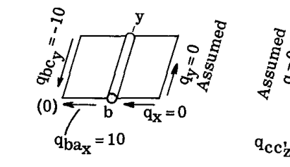

Fig. (A)

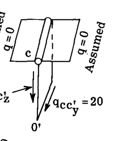

Fig. (B)

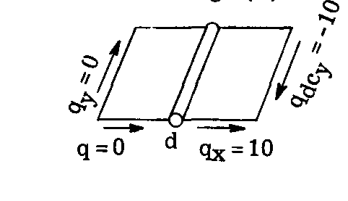

Fig. (C)

ウェブパネル $cc'$ のせん断流を得るために、計算は点 $c$ から開始し、点 $c'$ に向かって進んだ。このパネルの $q$ は $-20$ と計算された。図Bの自由体は、この $q_y = -20$ の値を示しており、その真の方向、すなわち点(O’)に向かって作用している。したがって、 $q_{cc'_z}$ も図Bに示すように、点(O’)に向かって作用しなければならない。図Cの自由体は、 $q_{de_x}$ の方向がどのように得られたかを示している。

図 A15.32は、図 A15.31のせん断流システムに加えられたときに、同一のセルねじれを生じさせるために、セル(1)および(2)にそれぞれ作用しなければならない未知の一定せん断流システム $q_1$ と $q_2$ を示している。 $q_1$ と $q_2$ の方向は、各セルにおいて時計回り、すなわち正と仮定されている。

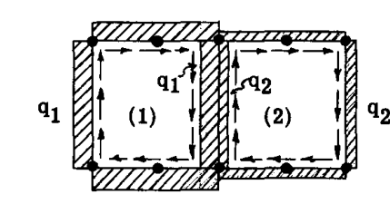

Fig. A15-32

梁の単位長さあたりの角ねじれ $\theta$ の方程式は、

$$2AG\theta = \sum q \frac{L}{t}$$

図 A15.31および32のせん断流値を使用して、各セルの角ねじれは、上記の方程式に代入することによって計算される。

**セル (1) について**

したがって、

$$2A_1 G \theta_1 = 1200q_1 - 333q_2 - 6670 \quad \cdots (1)$$

**セル (2) について**

$$2A_2 G \theta_2 = \frac{10 \times 5 \times 2}{0.03} + \frac{30 \times
10}{0.04} - \frac{20 \times 10}{0.03} + \frac{3 \times 10q_2}{0.03} +
\frac{10q_2}{0.04} - \frac{10q_1}{0.03}$$

したがって、

$$2A_2 G \theta_2 = -333q_1 + 1250q_2 + 4170 \quad \cdots (2)$$

セル間の連続性が存在するため、 $\theta_1 = \theta_2$ である。また、各セルの面積は同じであるため、 $A_1 = A_2$ である。(1)と(2)を等しく置くと、

$$1533q_1 - 1583q_2 - 10840 = 0 \quad \cdots (3)$$

未知数 $q_1$ と $q_2$ を解くには、もう1つの方程式が必要であり、それは断面の平面内の任意の点の回りにおける外部および内部のせん断力のモーメントの和によって与えられ、平衡のためにゼロに等しくなければならない。

図 A15.31および A15.32のせん断流システムの点(b)、およびこの場合は想定されたモーメント中心に関してモーメントを持たない $1000 \text{ lb.}$ の外部せん断荷重についてモーメントを取る。

$$\sum M_b = -50 \times 10 \times 5 + 20 \times 10 \times 5 + 10 \times 30
\times 15 + 200q_1 + 200q_2 = 0$$

したがって、

$$200q_1 + 200q_2 + 3000 = 0 \quad \cdots (4)$$

$q_1$ と $q_2$ について方程式(3)と(4)を解くと、次が得られる。

$$q_1 = -4.07 \text{ lb./in.}, \quad q_2 = -10.80 \text{ lb./in.}$$

最終または真の内部せん断流システムは、図 A15.31のものに、 $q_1 = -4.07$ および $q_2 = -10.80 \text{ lb./in.}$ のときの図 A15.32のものを加えたものに等しくなり、図 A15.33のせん断流図が得られる。

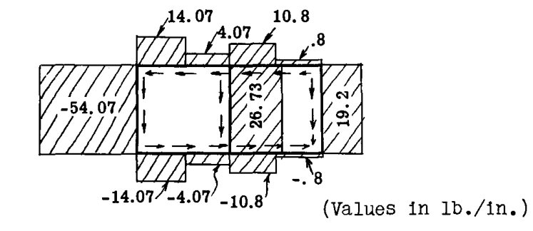

Fig. A15-33

### 解法2（せん断中心の使用による方法）

この解法では、ねじれなしでX-X軸の回りに曲げるための曲げせん断流を求める。この内部せん断システムの図心はせん断中心を特定する。せん断中心の回りの外部せん断荷重のモーメントは、2セル梁に純粋なねじりを与える。したがって、この純粋なねじりによるせん断を純粋な曲げによるせん断に加えることで、最終的な抵抗せん断流を得る。

ねじれなしでX-X軸の回りに曲げる場合、式(1)および(2)で与えられる各セルのせん断ひずみはゼロに等しくなければならない。したがって：

$$1200 q_1 - 333 q_2 - 6670 = 0 \quad \cdots (5)$$

$$-333 q_1 + 1250 q_2 + 4170 = 0 \quad \cdots (6)$$

$q_1$ と $q_2$ について方程式(5)と(6)を解くと、次が得られる。

$$q_2 = -2.0 \text{ lb./in.}, \quad q_1 = 5.00 \text{ lb./in.}$$

したがって、図 A15.32における $q_1$ と $q_2$ のこれらの値を取り、その結果を図 A15.31のものに加えると、図 A15.34のせん断流パターンが得られる。これは、X軸の回りにねじれなしで曲げるためのせん断流システムである。このせん断システムの図心はせん断中心を特定する。

図 A15.34において、

$$\sum V = 0 = -10 \times 45 - 10 \times 28 - 10 \times 27 = -1000 \text{
lb.}$$

これは $1000 \text{ lb.}$ の外部せん断を検証する。 $\sum H = 0$ は図 A15.34の観察による。

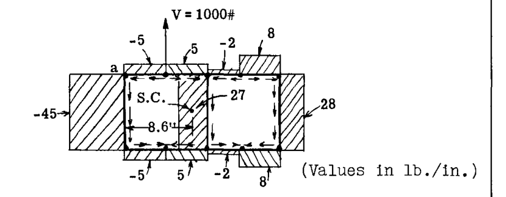

Fig. A15-34

図 A15.34におけるせん断流の図心の水平位置を求めるために、点 $a$ の回りでモーメントを取る：

$$\sum M_a = 10 \times 27 \times 10 + 10 \times 28 \times 20 + 5 \times 8
\times 10 - 5 \times 2 \times 10 = 8600 \text{ in. lb.}$$

したがって、

$$\bar{x} = \frac{8600}{1000} = 8.6'' \quad (\text{ウェブ }
aa' \text{ の右側})$$

$1000 \text{ lb.}$ の外部せん断荷重は $aa'$ の右側 $5''$ に作用するため、せん断中心の回りにおけるモーメントは次のように等しくなる：

$$(8.6 - 5.0) \times 1000 = 3600 \text{ in.lb.}$$

このねじりモーメントに抵抗するために、一定のねじりせん断流 $q_{t(1)}$ と $q_{t(2)}$ がそれぞれセル(1)と(2)に作用しなければならない。

$$_t(1) = -\frac{1}{2} \left[ \frac{a_{20} A_1 + a_{12} A}{a_{20} a_{12}^2
+ a_{12} a_2^2 + a_{01} a_2^2} \right] T$$

$$_t(1) = -\frac{1}{2} \left[ \frac{\left(\frac{10}{0.03} +
\frac{10}{0.04} + \frac{10}{0.03}\right) 100 + \frac{10}{0.03} \times
200}{\left(\frac{10}{0.03} + \frac{10}{0.04} + \frac{10}{0.03}\right)
100^2 + \frac{10}{0.03} \times 200^2 + \left(\frac{10}{0.03} +
\frac{10}{0.05} + \frac{10}{0.03}\right) 100^2} \right] T$$

$$= \frac{1}{2} \left[ \frac{158200}{31190000} \right] T = .00254T$$

外部トルクは $3600 \text{ in.lb.}$ に等しいため、抵抗する内部トルクは $-3600$ に等しくなければならない。したがって、

$$_t(1) = .00254(-3600) = -9.17 \text{ lb./in.}$$

$q_{t(2)}$ について解くと、

$$_t(2) = \frac{1}{2} \left[ \frac{a_{01} A_2 + a_{12} A}{31190000}
\right] T$$

$$= \frac{1}{2} \left[ \frac{\left(\frac{10}{0.03} + \frac{10}{0.03} +
\frac{10}{0.05}\right) 100 + \frac{10}{0.03} \times 200}{31190000}
\right] T = .00245T$$

したがって、

$$_t(2) = .00245 \times -3600 = -8.85 \text{ lb./in.}$$

したがって、図 A15.34のせん断流システムに、セル(1)に $-9.17 \text{ lb./in.}$ 、セル(2)に $-8.85 \text{ lb./in.}$ の一定のせん断流を加えると、図 A15.35の真の内部抵抗せん断流が得られ、これは解法1を検証する。不一致は計算尺の精度によるものである。

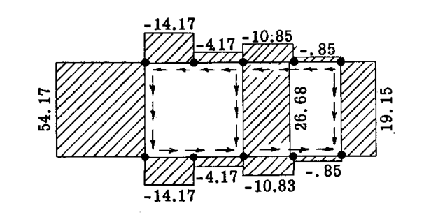

Fig. A15-35

### ねじりたわみ

各セルの角ねじれは同じである。梁の単位長さあたりの角ねじれ $\theta$ の値は、真の結果得られるせん断流である図 A15.35のせん断流パターン、または必要に応じて $q_{t(1)} = -9.17 \text{ lb./in.}$ および $q_{t(2)} = -8.85 \text{ lb./in.}$ の純粋なねじりせん断流を使用して見つけることができる。

結果は当然同じになる。例えば：

$q_{t(1)} = -9.17 \text{ lb./in.}$ および $q_{t(2)} = -8.85 \text{ lb./in.}$ によるセル(1)について：

$$2AG\theta_1 = \frac{\sum qL}{t} = \left(\frac{9.17 \times
10}{0.03}\right) 3 + \frac{9.17 \times 10}{0.05} - \frac{8.85 \times
10}{0.03}$$

$$= 8000$$

**セル (2)**

$$= 8000$$

**セル (1) 最終応力 - 図 A15.35**

$$2AG\theta_1 = \frac{\sum qL}{t} = \frac{(14.17 \times 5)^2}{(0.03)} +
\frac{(4.17 \times 5)^2}{(0.03)} + \frac{54.17 \times 10}{0.05}$$

$$- \frac{26.68 \times 10}{0.03} = 8000$$

**セル (2) 最終応力**

$$2AG\theta_2 = \frac{\sum qL}{t} = \frac{(10.85 \times 5)^2}{(0.03)} +
\frac{(0.85 \times 5)^2}{(0.03)} + \frac{26.68 \times 10}{0.03}$$

$$- \frac{19.15 \times 10}{0.04} = 8000$$

## A15.10 3セル - 複数フランジ梁。1軸対称。

図 A15.36は、示されているように $1000 \text{ lbs.}$ の外部せん断荷重を受ける3セル箱型梁を示している。断面は軸XXに対して対称である。各ストリンガーの面積は、各ストリンガー点に括弧で示されている。 $1000 \text{ lbs.}$ の外部荷重に抵抗する内部せん断流システムは、ウェブと壁が曲げ荷重を受け持たない、またはストリンガーが曲げにおいて唯一の有効な材料であると仮定して計算される。有効材料のXX軸に関する慣性モーメントは $250 \text{ in.}^4$ に等しい（注：この梁の断面は、図 A15.30の2セル梁に前縁セル(3)を加えたものと同一である）。

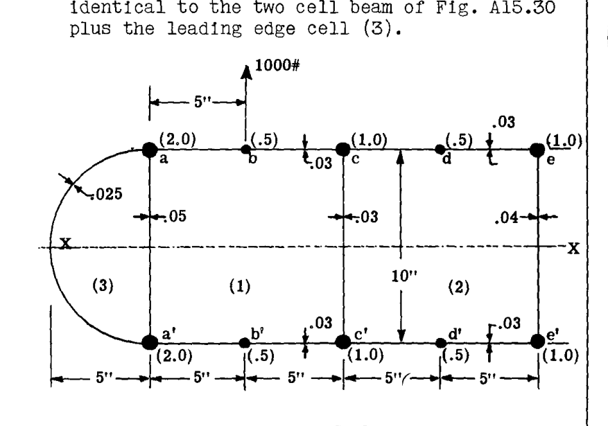

Fig. A15-36

### 解法 No. 1（せん断中心を使用しない方法）

各セル内の任意の点におけるせん断流 $q$ の値が未知であるため、システムは3次不定である。

せん断流の値は各セルのある点で仮定され、XX軸に関する曲げに対する曲げせん断流はこの仮定と一致して決定される。セル(1)、(2)、(3)のそれぞれについて、定数の未知のせん断流 $q_1$ 、 $q_2$ 、 $q_3$ が静的な曲げせん断流に加えられ、各セルの角ねじれ $\theta$ が同じになるようにされる。ねじれが発生した場合、すべてのセルが同じ量だけ変化しなければならないためである。さらに、平衡のために、内部せん断流システムのモーメントに外部せん断荷重のモーメントを加えたものはゼロに等しくなければならない。

軸XXの回りの曲げについて、曲げせん断流は、セル(3)のストリンガー $a$ のすぐ左側、およびセル(1)と(2)のそれぞれにおけるストリンガー $c$ のすぐ左側と右側でゼロと仮定される。これら3つの点でセルが切断されていると考えることができる。図 A15.37は、これらの仮定の下での曲げせん断流を示している。前縁セル(3)にはストリンガーがなく、被覆は曲げにおいて無効と見なされるため、せん断流はストリンガー $a$ のすぐ左側でゼロと仮定されたため、前縁部分のせん断流はゼロになる。したがって、3セル断面の得られる曲げせん断流は図 A15.31と同一になり、曲げせん断流の計算はArt. A15.7のものと同一になる。

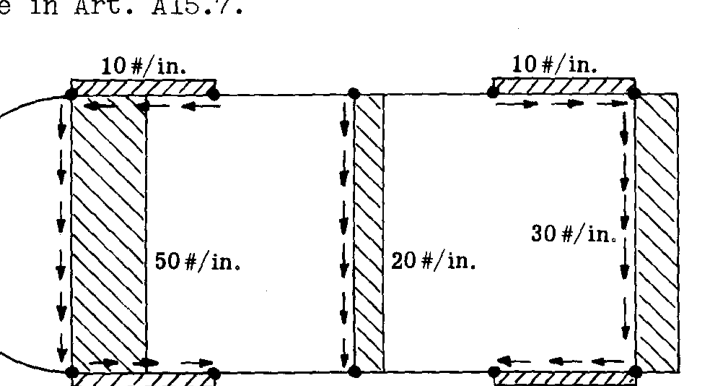

Fig. A15-37

図 A15.38は、各セルのねじれ $\theta$ を同じにするために、図 A15.37の曲げせん断流に加えられなければならない未知の一定せん断流 $q_1$ 、 $q_2$ 、 $q_3$ を示している。それぞれの方向は、各セルにおいて正（時計回り）と仮定されている。

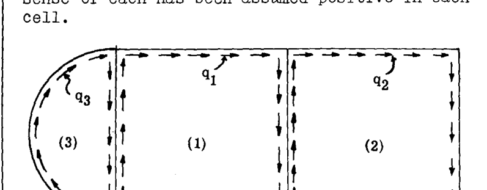

Fig. A15-38

各セルの角ねじれ $\theta$ は、 $\theta = \frac{1}{2AG} \sum q \frac{L}{t}$ に等しい。

図 A15.37および A15.38の $q$ の値を使用して、各セルについて $\theta G$ の値が計算される。

**セル (3)**

$$2\theta_3 G = \frac{\sum qL}{t}$$

$$2\theta \times 39.4G = \frac{10 \times 50}{0.05} +
\frac{15.71}{0.025}q_3 + \frac{10q_3}{0.05} - \frac{10q_1}{0.05}$$

または、

$$\theta G = 10.5q_3 - 2.55q_1 + 127 \quad \cdots (1)$$

**セル (1)**

$$2\theta_1 G = \frac{\sum qL}{t}$$

$$2\theta \times 100G = \frac{-50 \times 10}{0.05} - \frac{2(10 \times
5)}{0.03} + \frac{10 \times 20}{0.03} + \frac{3(10q_1)}{0.03}$$

$$+ \frac{10q_1}{0.05} - \frac{10q_3}{0.05} - \frac{10q_2}{0.03} \text{
したがって } \theta G = 6q_1 - q_3 - 1.67q_2 - 33.34 \quad \cdots (2)$$

**セル (2)**

$$2\theta_2 G = \frac{\sum qL}{t}$$

$$2\theta \times 100 \times G = -\frac{20 \times 10}{0.03} + \frac{2(10
\times 5)}{0.03} + \frac{10 \times 30}{0.040} +$$

$$\frac{3 \times 10 \times q_2}{0.03} + \frac{10q_2}{0.04} -
\frac{10q_1}{0.03} \text{ したがって } \theta G = 6.25q_2 - 1.67q_1 +
20.83 \quad \cdots (3)$$

図 A15.37および A15.38の内部せん断流システム、およびストリンガー $a$ の回りの $1000 \text{ lbs.}$ の外部荷重のモーメントを取り、ゼロに等しく置く：

$$\sum M_a = 10 \times 20 \times 10 + 10 \times 30 \times 20 - 5 \times
1000 + 78.6q_3 + 200q_1 + 200q_2 = 0$$

$$= 3000 + 78.6q_3 + 200q_1 + 200q_2 = 0 \quad \cdots (4)$$

未知数 $q_1$ 、 $q_2$ 、 $q_3$ 、および $\theta G$ について方程式(1)、(2)、(3)、(4)を解くと、次が得られる：

$$q_1 = -2.12 \text{ lb./in.}$$

$$q_2 = -7.09 \text{ lb./in.}$$

$$q_3 = -14.5 \text{ lb./in.}$$

$$\theta G = -19.9$$

これらの一定のせん断流を図 A15.37の曲げせん断流に加えることで、図 A15.39に示す真の内部抵抗せん断流を得る。

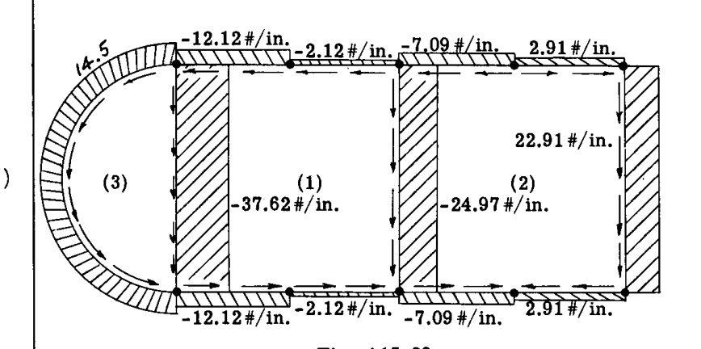

Fig. A15-39

## A15.11 多セル梁のせん断流。逐次近似法。

第A6章のArt. A6.13では、多セル梁が純粋なねじりモーメントを受けたときの抵抗せん断流システムを決定することにより、逐次近似法が提示された。このアプローチ方法は、梁がねじれなしで曲げを受けるときの抵抗せん断流を決定するために拡張された。これら2つの方法を使用すると、比較的多数のセルを持つ梁のせん断流を、多数の方程式を解く通常の方法と比較して、かなり迅速に決定できる。

### 方法の物理的説明

図 A15.40は、断面のせん断中心を通って作用する外部せん断荷重Vを支持する3セル梁を示しているが、位置はまだ未知である。言い換えれば、梁はねじれなしで対称軸X-Xの回りに曲がる。問題は、ねじれなしで曲げるための内部抵抗せん断流システムを決定することである。この例では、図の小さな円で表されるフランジ部材によって曲げモーメントが完全に抵抗されると仮定されている。これは、せん断流がフランジ部材間で一定になることを意味する。

解法の最初のステップは、構造をねじれなしの曲げに対するせん断流応力に関して静定にすることである。図 A15.41では、示されているように点a、b、cで各セルが切断されていると仮定する。与えられたせん断荷重Vについて、静的せん断流 $q_s$ は、修正された断面がねじれなしでX軸の回りに曲がると仮定して計算できる。図 A15.41は、この静的せん断流パターンの一般的な形状を示している。

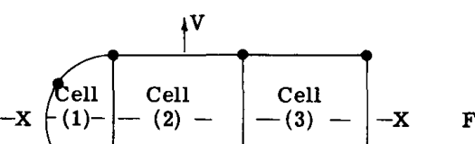

Fig. A15-40

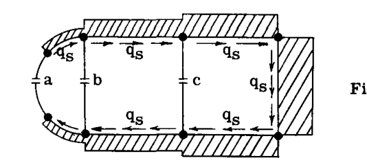

Fig. A15-41

ここで、各セルを個別のセルとして考える。各セルに作用する静的せん断流 $q_s$ は、各セルをねじれさせる。ねじれゼロが必要であるため、図 A15.42に示すように、セル(1)に一定のせん断流 $q'_1$ 、セル(2)に $q'_2$ 、セル(3)に $q'_3$ を加えなければならず、その大きさは各セルのねじれをゼロにするような値でなければならない。しかし、セルは実際には分離されておらず、隣接するセル間に共通のウェブを持っているため、せん断流 $q'_2$ はセル(1)の一部であるウェブ2-1に作用し、したがってセル(1)をねじれさせる。同様に、セル(3)は $q'_2$ によってねじられ、セル(2)は $q'_1$ と $q'_3$ の両方によってねじられる。したがって、この追加のセルねじれを相殺するために、図 A15.43に示すように追加の一定せん断流 $q''_1$ 、 $q''_2$ 、 $q''_3$ を加え、再び各セルを個別に考慮しなければならない。しかし、セルは分離されていないため、これらの追加のせん断流は共通のウェブを通じて隣接するセルのねじれに影響を与える。以前と同様に、セルねじれにおけるこの乱れは、図 A15.44に示すように、さらに閉じるせん断流 $q'''_1$ 、 $q'''_2$ 、 $q'''_3$ を加えることによって再び相殺されるかゼロにされる。この手順は、閉じるせん断流が無視できるようになるまで繰り返される。一般に、このシステムの収束は非常に迅速であり、所望の計算精度を得るためには数サイクルしか必要としない。

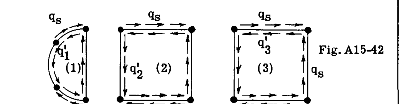

Fig. A15-42

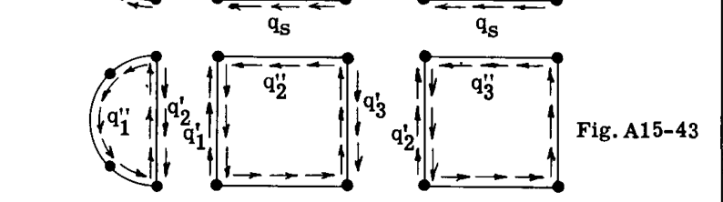

Fig. A15-43

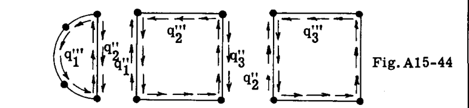

Fig. A15-44

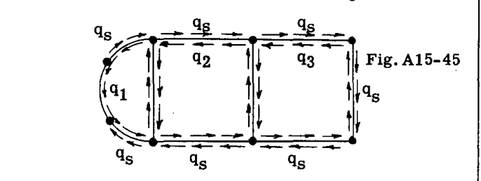

Fig. A15-45

したがって、総閉じるせん断流 $q_1$ 、 $q_2$ 、および $q_3$ は次と等しくなる：

$$q_1 = q'_1 + q''_1 + q'''_1 + \cdots$$

$$q_2 = q'_2 + q''_2 + q'''_2 + \cdots$$

$$q_3 = q'_3 + q''_3 + q'''_3 + \cdots$$

任意のパネルにおける最終的なせん断流は、次のようになる（図 A15.45を参照）：

$$q = q_s + q_1 + q_2 + q_3 \quad \cdots (1)$$

この最終的なせん断流システムの図心は、X軸に関する曲げに対する、断面のせん断中心の位置を特定する。

### 逐次近似法で使用するための方程式の導出

図 A15.46は、図 A15.45に示されている3セル梁のセル(2)を示している。 $q_s$ は静的せん断流であり、 $q_1$ 、 $q_2$ 、および $q_3$ は冗長または未知のせん断流である。セル(2)はこれらのせん断流の下でねじれないため、一般に次のように書くことができる：

$$\sum q \frac{L}{t} = 0 \quad \cdots (1)$$

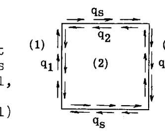

Fig. A15-46

図 A15.46のセル(2)におけるさまざまなせん断流を式(1)に代入すると、

$$\sum_2 q_s \frac{L}{t} - q_2 \sum_2 \frac{L}{t} + q_1 \sum_{1-2}
\frac{L}{t} + q_3 \sum_{3-2} \frac{L}{t} = 0 \quad \cdots (2)$$

総和記号の添字(2)はセル(2)の完全な周囲の総和を意味し、添字1-2および3-2はそれぞれウェブ1-2または3-2に沿った総和のみを意味する。Lは外板パネルの長さ、tはその厚さである。

式(2)を $q_2$ について解くと：

$$q_2 = \frac{\sum_2 q_s \frac{L}{t}}{\sum_2 \frac{L}{t}} + \left(
\frac{\sum_{1-2} \frac{L}{t}}{\sum_2 \frac{L}{t}} \right) q_1 + \left(
\frac{\sum_{3-2} \frac{L}{t}}{\sum_2 \frac{L}{t}} \right) q_3 \quad
\cdots (3)$$

式(3)の最初の項は、 $q_s$ によるねじれを相殺するために、セル(2)の回りに一定のせん断流として作用しなければならない静的せん断流 $q_s$ の割合を表している。この最初の項の得られる値には、記号 $q'_2$ が与えられる。

式(3)の2番目と3番目の項は、隣接するセル内の $q_1$ と $q_3$ がセル間の共通のウェブに作用することによる影響を相殺するために、セル(2)に必要とされる一定の閉じるせん断流を表している。式(3)の $q_1$ の前の比率は、セル(1)からセル(2)へのキャリーオーバー影響因子と呼ばれ、記号 $C_{1-2}$ が与えられ、式(3)の $q_3$ の前の比率は、セル(3)からセル(2)へのキャリーオーバー影響因子であり、記号 $C_{3-2}$ が与えられる。したがって、式(3)は次のように書くことができる：

$$q_2 = q'_2 + C_{1-2} q_1 + C_{3-2} q_3 \quad \cdots (4)$$

上記で説明したように、 $q'_2$ は、隣接するセルのせん断流がゼロのときに、ねじれゼロにするために必要な閉じるせん断流の値である。したがって、各セルにおける最終的なせん断流に対する最初の近似は、隣接するセルの影響を無視すること、言い換えれば、各セルを個別に考慮することによって得られる。したがって、最初の近似は次のようになる：

$$\left\{
\begin{aligned}
q_1 &\approx q'_1 \\
q_2 &\approx q'_2 \\
q_3 &\approx q'_3
\end{aligned}
\right. \quad \cdots (5)$$

(5)を(4)に代入することにより、 $q_2$ に対する2番目の近似が得られ、すなわち、

$$q_2 \approx q'_2 + C_{1-2} q'_1 + C_{3-2} q'_3 \quad \cdots
(6)$$

または、

$$q_2 = q'_2 + q''_2 \quad \cdots (7)$$

ここで、 $q''_2$ は最初の近似に加えられる修正である。同様の方法で、修正 $q''_1$ と $q''_3$ が $q_1$ と $q_3$ の近似に対して行われる。したがって、 $q_2$ に対する3番目の見積もりとして、これらのさらなる修正を加える必要があり、したがって方程式(7)は次のようになる：

$$q_2 \approx q'_2 + C_{1-2} (q'_1 + q''_1) + C_{3-2}
(q'_3 + q''_3) \quad \cdots (8)$$

したがって、上記の手順を繰り返すことにより、キャリーオーバー影響因子のべき級数が得られる。一般に、収束は迅速であり、最終的なせん断流に対して十分な精度を得るためには、比較的わずかなサイクルまたは演算しか必要としない。必要とされる演算が非常に単純なルーチンを構成することを示すために、ここで問題の解法を示す。

### A15.12 例題の解法。問題 No. 1。

この例題では、フランジ部材がすべての曲げ応力抵抗を受け持つと仮定され、この仮定により、せん断流は隣接するフランジ部材間で一定になる。

総上部フランジ面積は $5.5 \text{ in.}^2$ に等しく、総下部フランジ面積も等しい。対称性のため、重心X軸は中間の高さの位置にある。

したがって、

$$I_x = (5.5 \times 5^2) \times 2 = 275 \text{ in.}^4$$

$$q_s = -\frac{V_z}{I_x} \sum Z A = -\frac{1000}{275} \sum Z A = -3.636
\sum Z A$$

左下の角から開始して、静的せん断流 $q_s$ は梁の回りを反時計回りに計算される。

$$q_{ab} = -3.636(-5) \times 2 = 36.36 \text{ lb./in.}$$

$$q_{bc} = 36.36 - 3.636(-5) \times 1 = 54.55 \text{ lb./in.}$$

$$q_{cd} = 54.55 - 3.636(-5) \times 0.5 = 63.64$$

梁の回りを同様の方法で継続すると、図 A15.48に示す $q_s$ の値が得られる。

図示されているようにセルラー梁、および表内の数値は、示されているようにセルに対応して整列されるべきである。

表 A15.2に提示されている解法は、17の単純なステップで実行される。表の行1に示されている最初のステップは、各セルについて次の値を計算することである：

$$\sum q_s \frac{L}{t}$$

ここで、 $q_s$ はセルの各外板パネルにおける静的せん断流、Lはパネルの長さ、tはその厚さである。 $q_s$ の値は図 A15.48から取得される。

例えば、セル1について：

$$\sum q_s \frac{L}{t} = 2(36.36 \times 10) \frac{1}{0.04} = 18180$$

$q_s$ が正（セル上の時計回りのせん断流は正）であるため、符号は正である。表の行1は、5つのセルについて計算された値を示している。

表の行2に示されている2番目のステップは、各セルについて式 $\sum L/t$ の値を計算することである。

例えば、セル1について、

$$\sum_1 \frac{L}{t} = \frac{10}{0.064} + \frac{(10)2}{0.04} +
\frac{10}{0.05} = 856$$

セル2について、

$$\sum_2 \frac{L}{t} = \frac{10}{0.05} + \frac{2(10)}{0.04} +
\frac{10}{0.04} = 950$$

行3に示されている3番目のステップは、2つの隣接するセル間の共通ウェブの $L/t$ の値を計算することである。

例えば、セル(1)と(2)の間のウェブ $bb'$ について、

$$\left(\frac{L}{t}\right)_{1-2} = \frac{10}{0.05} = 200$$

4番目のステップは、あるセルから隣接するセルへのキャリーオーバー因子を決定することである。結果は表の行4に記録される。

一般的な説明のために方程式(3)を参照すると、セル(1)からセル(2)へのキャリーオーバー因子は、

$$C_{1-2} = \frac{\left(\frac{L}{t}\right)_{1-2}}{\sum_2 \frac{L}{t}} =
\frac{200}{950} = .2105$$

であり、セル(2)からセル(1)へのキャリーオーバー因子は次のようになる：

$$C_{2-1} = \frac{\left(\frac{L}{t}\right)_{2-1}}{\sum_1 \frac{L}{t}} =
\frac{200}{856} = .2336$$

これで、逐次近似による本来の解法を開始する準備が整った。表の行5において、最初の近似は、各セルに値 $q'$ が加えられ、セルウェブが切断されていないときに静的せん断流によるねじれを相殺するが、各セルは他から分離または独立していると見なされることである。この一定の閉じるせん断流 $q'$ は次と等しくなる：

$$q' = -\frac{\sum q_s \frac{L}{t}}{\sum \frac{L}{t}}$$

静的せん断流によるねじれを相殺しなければならないため、マイナス符号が必要である。 $q'$ の値は表の行5に記録されている。

例えば、セル(1)について、

$$q' = -\frac{18180}{856} = -21.238$$

セル(2)について、

$$q' = -\frac{27275}{950} = -28.71$$

表の行6から13に記録されているステップ6から13は、操作において同一であり、すなわち、共通ウェブのためにあるセルから隣接するセルへのキャリーオーバー影響である。閉じるせん断流が各セルに加えられて、それらが分離していると見なされたときにセルのねじれをゼロにすると、この結果は共通ウェブのために継続的に乱される。徐々に、これらの修正せん断流は、セルが真の状態に達し、ねじれがゼロになるまで、ますます小さくなる。表では、操作を明確にするために、2サイクルの間矢印が使用されている。

例えば、行6において、セル(1)からセル(2)へのキャリーオーバーせん断流は、

$$-6.700 \times .2105 = -1.414$$

行14の結果は、かなりの数の乗算と数値の加算の後に得られるため、計算ミスを犯しやすい。重大な間違いが犯されていないかを確認するために、行14の値を取り、セルが分離している場合にゼロねじれを引き起こすものとして、各セルにおける一定せん断流のこれらの値を考慮する。次に、共通ウェブを通じてセルを一緒にすると、ねじれに乱れが生じ、これはキャリーオーバー値によってゼロにされる。表におけるこのステップは、再反復（reiteration）と呼ばれ、行15に示されている。次に行15の値を、行16に繰り返される行5の初期近似 $q'$ に加えると、行17における最終的な $q$ の値が得られる。行17の値は、行14のものと事実上同じ大きさであり、したがって重大な間違いは犯されていない。差が顕著であった場合は、2回目、必要に応じてさらに多くの回数の再反復を実行する必要がある。表では、行18、19、20に2回目の再反復が示されており、行20の結果は行17のものと事実上同じである。

### 問題1の解法2

解法1において、想定された静的条件は、右端のウェブを除くすべての垂直ウェブを切断することを含んでいた。したがって、静的梁断面は開チャネル断面になり、得られる静的せん断流は、ねじれなしの曲げにおいてウェブが常に大きなせん断流を負担するため、最終的な真のせん断流値とは明らかに大きく異なるに違いない。この事実は、最終的な結果に十分な精度を与えるために、連続する修正が十分に小さくなる状態に達するために表 A15.2において比較的多数のステップが必要であったことによって示されている。したがって、ウェブ内の静的せん断流が最終値にはるかに近く、したがって逐次近似手順における収束を早めるような静的条件を想定することが論理的である。

## A15.13 例題2。

すべての材料が曲げ抵抗に有効である場合。

水平重心軸に関する全断面の慣性モーメントは、

上下外板についての $I_x$ 、

$$= (50 \times 0.125 \times 2.5^2) \times 2 = 78.0$$

すべてのウェブについての $I_x$ 、

$$= (0.912 \times 5^3) / 12 = 9.5$$

$$\text{合計 } I_x = 87.5 \text{ in.}^4$$

便宜上、外部せん断荷重 $V_z = 8750 \text{ lb.}$ がこの梁断面に作用していると仮定する。

したがって、

$$q = -\frac{V_z}{I_x} \sum Z A = -\frac{8750}{87.5} \sum Z A = -100 \sum
Z A$$